# Electoral Commission digital imprints experiment

Analysis of pre-registered hypotheses

Kate Dommett

Tom Stafford

Junyan Zhu

Hazel Gordon

### Preparing the dataset

#### Libraries used

```r
library(dplyr)
library(tidyr)
library(stringr)
library(purrr)
```

#### Reading in data and exclusions

```r
pilotdata <- read.csv("pilot_data.csv")

#EXCLUSION FOR PILOT DATA ONLY (MISSING VALUE, now forced response added on qualtrics)

n <- 34
pilotdata <- pilotdata[-n, ]

#extract relevant variables into new data frame

data <- pilotdata %>%
  select(Training.condition, Advert.1, Advert.2, Advert.3, Advert.4, starts_with("PK"), starts_with("agree"), starts_with("informed"), starts_with("accurate"), starts_with("believable"), starts_with("trustworthy"), starts_with("factual"), election_reg, recall_num, recall_name, starts_with("useful"), reg_know, starts_with("EPE"), starts_with("general_confidence"), starts_with("institution"), democracy, political_interest, external_efficacy, internal_efficacy, starts_with("SM"), partyID, age, gender, education)

#removing top 2 rows

data <- data %>%
  slice(-c(1, 2))

#give each participant a number identifier

data <- data %>%
  mutate(id = row_number())

#moving id identifier to the front

data <- data %>%
  select(id, everything())
```

#### Agree/disagree item transformations

The code below will convert all variables with response measurement of strongly disagree to strongly agree from a character variable to a numerical scale of 1-7. One item also needs to be reverse scored:

- Informed item 3: ‘I am not sure who is behind this material’

There are also attention checks in the dataset that need to be removed **once exclusions have been dealt with**:

- informed_2_5
- informed_2imprint_5
- EPE_5

Below creates a functions that will be applied to all agree-disagree response formats in the dataset - all ones that start with PK, agree, informed, EPE and general_confidence. The second function then reverse scores informed item three across the eight advert variations.

**different scale options for agree, epe and general_confidence**

```r
#converting to numeric variables from character for agree - disagree

#THIS CURRENTLY WON'T WORK FOR AGREE, EPE, INFORMED and GENERAL: CHANGE RESPONSE OPTIONS ON QUALTRICS

# Define the function to convert responses to numeric
convert_responses_to_numeric <- function(response) {
  # Define the mapping from response to numeric value
  mapping <- c(
    "Strongly disagree" = 1,
    "Somewhat disagree" = 2,
    "Slightly disagree" = 3,
    "Neither agree nor disagree" = 4,
    "Slightly agree" = 5,
    "Somewhat agree" = 6,
    "Strongly agree" = 7
  )

  # Replace the character response with its corresponding numeric value
  return(mapping[response])
}

convert_2 <- function(response) {

  mapping <- c(
    "Strongly disagree" = 1,
    "Disagree" = 2,
    "Somewhat disagree" = 3,
    "Neither agree nor disagree" = 4,
    "Somewhat agree" = 5,
    "Agree" = 6,
    "Strongly agree" = 7
  )

  return(mapping[response])
}

#applying this function to the data frame (two separate functions to account for differences in response options)

data <- data %>%
  mutate(across(c(starts_with("PK")), ~convert_responses_to_numeric(.x)))

data <- data %>%
  mutate(across(c(starts_with("informed"), starts_with("agree"), starts_with("EPE"), starts_with("general")), ~convert_2(.x)))

#reverse scoring informed item 3

reverse_code <- function(response) {
  # Define the mapping from original to reversed scores
  mapping <- c(1, 2, 3, 4, 5, 6, 7)
  names(mapping) <- c(7, 6, 5, 4, 3, 2, 1)

  # Use the response as a name to look up in the mapping
  return(as.numeric(names(mapping)[match(response, mapping)]))
}

data <- data %>%
  mutate(across(c(informed_1_3, informed_1imprint_3, informed_2_3, informed_2imprint_3, informed_3_3, informed_3imprint_3, informed_4_3, informed_4imprint_3), ~reverse_code(.x)))

#removing the attention check columns from the dataset

data <- data %>%
  select(-informed_2_5, -informed_2imprint_5, -EPE_5)
```

#### Variable tranformations for both RM and IM dataframes

The code below conducts the following transformations to the variables that will be present in both the repeated measures and independent measures data frames so they are ready to be analysed:

- **Transformed to a factor**: advert.1, advert.2, advert.3, advert.4, Training.condition, reg_know, SM_use, starts with: SM_frequency, party_ID, gender, education
- **Transformed to a numerical variable**: election_reg, starts with: useful_rank, starts with: institution_trust, democracy, political_interest, external_efficacy, internal_efficacy, age

*Some variables will only be present in the repeated measures data frame and will be created later.*

```r
#creating factor variables through use of a function

convert_to_factor <- function(df, cols) {
  df %>%
    mutate(across(all_of(cols), as.factor))
}

data <- data %>%
  convert_to_factor(c("Advert.1", "Advert.2", "Advert.3", "Advert.4", "SM_frequency_1", "SM_frequency_2", "SM_frequency_3", "SM_frequency_4", "SM_frequency_5", "SM_frequency_6", "Training.condition", "reg_know", "SM_use", "partyID", "gender", "education"))

#Setting reference groups for: reg_know, SM_use, SM_frequency, gender, education

#regulation knowledge

reg_response_order <- c("There are no regulatory controls on any type of political advertising during UK elections", "All political advertising is regulated by rules set by the UK government, but there is one set of rules for advertising on television and radio and a different set of rules for advertising on the internet and social media", "All political advertising (whether on television, radio, in newspapers or the internet) is subject to the same rules set by the UK government", "Not sure")

data <- data %>%
  mutate(across(reg_know, ~factor(.x, levels = reg_response_order)))

#Social media use

use_response_order <- c("None, No time at all ", "Less than 1/2 hour ", "1/2 hour to 1 hour ", "1 to 2 hours ",  "Not sure")

data <- data %>%
  mutate(across(SM_use, ~factor(.x, levels = use_response_order)))

#SM frequency use

freq_response_order <- c("Never",
                         "Less than once a week",
                         "Once a week\t",
                         "Once every couple of days\t",
                         "Once a day\t",
                         "2-5 times a day\t",
                         "More than five times a day\t")

data <- data %>%
  mutate(across(starts_with("SM_frequency"), ~factor(.x, levels = freq_response_order)))

#gender OTHER WILL BE REMOVED FOR MAIN STUDY

gender_response_order <- c("Female", "Male", "Non-binary / third gender", "Other, please specify")

data <- data %>%
  mutate(across(gender, ~factor(.x, levels = gender_response_order)))

#Education level NOT ALL LEVELS USED IN PILOT, NEEDS UPDATING WHEN MAIN

ed_response_order <- c("GCSE level, or equivalent", "A-level, or equivalent", "Undergraduate University (e.g. BA, B.Sc, B.Ed)", "Postgraduate (e.g. M.Sc, Ph.D)")

data <- data %>%
  mutate(across(education, ~factor(.x, levels = ed_response_order)))
```

```r
#Need to first change response options from categories to numbers for: election_reg, institution_trust, democracy, political_interest, internal_efficacy, external_efficacy, age

#Confidence in electoral regulation

data <- data %>%
  mutate(election_reg = case_when(
    election_reg == "Completely insufficient" ~ 1,
    election_reg == "Mostly insufficient" ~ 2,
    election_reg == "Slightly insufficient" ~ 3,
    election_reg == "No opinion/not sure" ~ 4,
    election_reg == "Slightly sufficient" ~ 5,
    election_reg == "Mostly sufficient" ~ 6,
    election_reg == "Completely sufficient" ~ 7
  ))

#CHANGES TO INSTITUTION TRUST WILL NOT BE NEEDED FOR FINAL DS

#changing '0 - none at all' to 0 for institution_trust

data <- data %>%
  mutate(across(starts_with("institution_trust"), ~ case_when(
    .x == "0 - none at all" ~ 0,
    TRUE ~ as.numeric(.x)
  )))
#Converting 'democracy' to a numeric variable

data <- data %>%
  mutate(democracy = case_when(
    democracy == "Very dissatisfied" ~ 1,
    democracy == "A little dissatisfied" ~ 2,
    democracy == "Fairly satisfied" ~ 3,
    democracy == "Very satisfied" ~ 4
  ))

#converting political interest to a numerical variable

data <- data %>%
  mutate(political_interest = case_when(
    political_interest == "Not at all interested" ~ 1,
    political_interest == "Not very interested" ~ 2,
    political_interest == "Slightly interested" ~ 3,
    political_interest == "Fairly interested" ~ 4,
    political_interest == "Very interested " ~ 5
  ))

#converting internal and external efficacy to numeric, 5 options

data <- data %>%
  mutate(internal_efficacy = case_when(
    internal_efficacy == "Not at all " ~ 1,
    internal_efficacy == "A little " ~ 2,
    internal_efficacy == "A moderate amount  " ~ 3,
    internal_efficacy == "A lot " ~ 4,
    internal_efficacy == "A great deal " ~ 5
  ))

data <- data %>%
  mutate(external_efficacy = case_when(
    external_efficacy == "Not at all " ~ 1,
    external_efficacy == "A little " ~ 2,
    external_efficacy == "A moderate amount  " ~ 3,
    external_efficacy == "A lot " ~ 4,
    external_efficacy == "A great deal " ~ 5
  ))

#transforming age from a date to an age

current_year <- format(Sys.Date(), "%Y")

current_year <- as.numeric(current_year)
data$age <- as.numeric(data$age)

data$age <- current_year - data$age

#creating numeric variables through the use of a function

convert_to_numeric <- function(df, cols) {
  df %>%
    mutate(across(all_of(cols), as.numeric))
}

#Convert all other variables to numeric

data <- data %>%
  convert_to_numeric(c("useful_rank_1", "useful_rank_2", "useful_rank_3", "useful_rank_4", "useful_rank_5", "useful_rank_6"))
```

#### Recall variable transformations

Transformation of recall variables:

- **Recall_num**: two new columns need to be created specifying those who picked ‘not sure’ versus those who chose an answer, then those who were correct, chose 2, and those who were incorrect.
- **Recall_name**: 8 potential columns will need to be created with a binary response, indicating whether each name option was identified e.g. ‘common sense collective’.
- The correct identification options are:
  - Common sense collective - advert 1
  - Breaking barriers alliance - advert 2
  - Speak freely Inc.- advert 3
  - Campaign for a better Britain - advert 4
- Incorrect options
  - Future first
  - The peoples movement
  - Voice for the people
  - Hope something - removed from qualtrics and replaced with ad 4
  - All together

A NAME IS MISSING FROM THE LIST IN QUALTRICS, CBB, NOW ADDED

```r
#Recall number transformation

#column one estimating perceived informedness, recall_answer

data <- data %>%
  mutate(recall_answer =
           case_when(
             recall_num == "Not sure" ~ 0,
             TRUE ~ 1
           ))

#column two showing actual informedness, recall_correct

data <- data %>%
  mutate(recall_correct =
           case_when(
             recall_num == 2 ~ "correct",
             TRUE ~ "incorrect"
           ))

#Recall name transformation, correct responses

data <- data %>%
  mutate(CSC = case_when(
    str_detect(recall_name, "Common Sense Collective") ~ 1,
    TRUE ~ 0
  ))

data <- data %>%
  mutate(BBA = case_when(
    str_detect(recall_name, "Breaking Barriers Alliance") ~ 1,
    TRUE ~ 0
  ))

data <- data %>%
  mutate(SFI = case_when(
    str_detect(recall_name, "Speak Freely Inc") ~ 1,
    TRUE ~ 0
  ))

data <- data %>%
  mutate(CBB = case_when(
    str_detect(recall_name, "Campaign for a better Britain") ~ 1,
    TRUE ~ 0
  ))

#incorrect responses

data <- data %>%
  mutate(FF = case_when(
    str_detect(recall_name, "Future First") ~ 1,
    TRUE ~ 0
  ))

data <- data %>%
  mutate(TPM = case_when(
    str_detect(recall_name, "The People’s movement") ~ 1,
    TRUE ~ 0
  ))

data <- data %>%
  mutate(VFP = case_when(
    str_detect(recall_name, "Voice for the People") ~ 1,
    TRUE ~ 0
  ))

data <- data %>%
  mutate(AT = case_when(
    str_detect(recall_name, "All Together") ~ 1,
    TRUE ~ 0
  ))

#number of correct names recalled, name_correct

data <- data %>%
  mutate(name_correct = CSC + BBA + SFI + CBB)

#number of incorrect names recalled, name_incorrect

#add incorrect columns together

data <- data %>%
  mutate(name_incorrect = FF + TPM + VFP + AT)

#convert campaign names to factors

data <- data %>%
  convert_to_factor(c("recall_answer", "recall_correct", "CSC", "BBA", "SFI", "CBB", "FF", "TPM", "VFP", "AT"))
```

#### Repeated measures dataframe

The code below turns the wide data into long data, creating 4 rows for each participant and only one column for each of the outcome variables: persuasion knowledge, political goal, informedness, agreement, believability, trustworthiness, accurateness, factual. Extra columns also specify the advert viewed and the version (imprint or no imprint).

```r
#create a new dataframe with only the repeated measures (post-advert) variables

RM <- data %>%
  select(id, starts_with("Advert."), starts_with("PK"), starts_with("agree"), starts_with("informed"), starts_with("accurate"), starts_with("believable"), starts_with("trustworthy"), starts_with("factual"))

#when first converted into long data, eight rows are generated for each participant for the eight different advert variations, but many columns contain NA.

#persuasion knowledge df, each item separate

PK1_long <- RM %>%
  select(id, starts_with("Advert."), PK_1_1, PK_1imprint_1, PK_2_1, PK_2imprint_1, PK_3_1, PK_3imprint_1, PK_4_1, PK_4imprint_1) %>%
  pivot_longer(
    cols = c(PK_1_1, PK_1imprint_1, PK_2_1, PK_2imprint_1, PK_3_1, PK_3imprint_1, PK_4_1, PK_4imprint_1),
    names_to = "PK1",
    values_to = "PK1_value"
  )

PK2_long <- RM %>%
  select(id, starts_with("Advert."), PK_1_2, PK_1imprint_2, PK_2_2, PK_2imprint_2, PK_3_2, PK_3imprint_2, PK_4_2, PK_4imprint_2) %>%
  pivot_longer(
    cols = c(PK_1_2, PK_1imprint_2, PK_2_2, PK_2imprint_2, PK_3_2, PK_3imprint_2, PK_4_2, PK_4imprint_2),
    names_to = "PK2",
    values_to = "PK2_value"
  )

PK3_long <- RM %>%
  select(id, starts_with("Advert."), PK_1_3, PK_1imprint_3, PK_2_3, PK_2imprint_3, PK_3_3, PK_3imprint_3, PK_4_3, PK_4imprint_3) %>%
  pivot_longer(
    cols = c(PK_1_3, PK_1imprint_3, PK_2_3, PK_2imprint_3, PK_3_3, PK_3imprint_3, PK_4_3, PK_4imprint_3),
    names_to = "PK3",
    values_to = "PK3_value"
  )

PK4_long <- RM %>%
  select(id, starts_with("Advert."), PK_1_4, PK_1imprint_4, PK_2_4, PK_2imprint_4, PK_3_4, PK_3imprint_4, PK_4_4, PK_4imprint_4) %>%
  pivot_longer(
    cols = c(PK_1_4, PK_1imprint_4, PK_2_4, PK_2imprint_4, PK_3_4, PK_3imprint_4, PK_4_4, PK_4imprint_4),
    names_to = "PK4",
    values_to = "PK4_value"
  )


#political goal df, informed item 1

PG_long <- RM %>%
  select(id, starts_with("Advert."), informed_1_1, informed_1imprint_1, informed_2_1, informed_2imprint_1, informed_3_1, informed_3imprint_1, informed_4_1, informed_4imprint_1) %>%
  pivot_longer(
    cols = c(informed_1_1, informed_1imprint_1, informed_2_1, informed_2imprint_1, informed_3_1, informed_3imprint_1, informed_4_1, informed_4imprint_1),
    names_to = "political_goal",
    values_to = "PG_value"
  )

#informed df, each item separate

informed2_long <- RM %>%
  select(id, starts_with("Advert."), informed_1_2, informed_1imprint_2, informed_2_2, informed_2imprint_2, informed_3_2, informed_3imprint_2, informed_4_2, informed_4imprint_2) %>%
  pivot_longer(
    cols = c(informed_1_2, informed_1imprint_2, informed_2_2, informed_2imprint_2, informed_3_2, informed_3imprint_2, informed_4_2, informed_4imprint_2),
    names_to = "informed2",
    values_to = "informed2_value"
  )

informed3_long <- RM %>%
  select(id, starts_with("Advert."), informed_1_3, informed_1imprint_3, informed_2_3, informed_2imprint_3, informed_3_3, informed_3imprint_3, informed_4_3, informed_4imprint_3) %>%
  pivot_longer(
    cols = c(informed_1_3, informed_1imprint_3, informed_2_3, informed_2imprint_3, informed_3_3, informed_3imprint_3, informed_4_3, informed_4imprint_3),
    names_to = "informed3",
    values_to = "informed3_value"
  )

informed4_long <- RM %>%
  select(id, starts_with("Advert."), informed_1_4, informed_1imprint_4, informed_2_4, informed_2imprint_4, informed_3_4, informed_3imprint_4, informed_4_4, informed_4imprint_4) %>%
  pivot_longer(
    cols = c(informed_1_4, informed_1imprint_4, informed_2_4, informed_2imprint_4, informed_3_4, informed_3imprint_4, informed_4_4, informed_4imprint_4),
    names_to = "informed4",
    values_to = "informed4_value"
  )

#agreement df

agree_long <- RM %>%
  select(id, starts_with("Advert."), starts_with("agree")) %>%
  pivot_longer(
    cols = starts_with("agree"),
    names_to = "agree",
    values_to = "agree_value"
  )

#trustworthy df

trustworthy_long <- RM %>%
  select(id, starts_with("Advert."), starts_with("trustworthy")) %>%
  pivot_longer(
    cols = starts_with("trustworthy"),
    names_to = "trustworthy",
    values_to = "trustworthy_value"
  )

#believability df

believe_long <- RM %>%
  select(id, starts_with("Advert."), starts_with("believable")) %>%
  pivot_longer(
    cols = starts_with("believable"),
    names_to = "believable",
    values_to = "believable_value"
  )

#accurateness df

accurate_long <- RM %>%
  select(id, starts_with("Advert."), starts_with("accurate")) %>%
  pivot_longer(
    cols = starts_with("accurate"),
    names_to = "accurate",
    values_to = "accurate_value"
  )

#factual df

factual_long <- RM %>%
  select(id, starts_with("Advert."), starts_with("factual")) %>%
  pivot_longer(
    cols = starts_with("factual"),
    names_to = "factual",
    values_to = "factual_value"
  )

#Create two new variables in each indicating advert type and version viewed, so that the dataframes can be merged by these two columns

#Below is three functions that can be applied to each df to create new variables.

# Function to add 'advert' and 'version' based on patterns in a specified column
add_advert_version <- function(data, column_name) {
  data %>%
    mutate(
      advert = case_when(
        str_detect(!!sym(column_name), "1") ~ "advert.1",
        str_detect(!!sym(column_name), "2") ~ "advert.2",
        str_detect(!!sym(column_name), "3") ~ "advert.3",
        str_detect(!!sym(column_name), "4") ~ "advert.4",
        TRUE ~ NA_character_
      ),
      version = case_when(
        str_detect(!!sym(column_name), "imprint") ~ 1,
        TRUE ~ 0
      )
    )
}

#apply function for agree, trust, believe, factual, accurate

agree_long <- add_advert_version(agree_long, "agree")
trustworthy_long <- add_advert_version(trustworthy_long, "trustworthy")
believe_long <- add_advert_version(believe_long, "believable")
accurate_long <- add_advert_version(accurate_long, "accurate")
factual_long <- add_advert_version(factual_long, "factual")

#PK function

PK_advert_version <- function(data, column_name) {
  data %>%
    mutate(
      advert = case_when(
        str_detect(!!sym(column_name), "PK_1") ~ "advert.1",
        str_detect(!!sym(column_name), "PK_2") ~ "advert.2",
        str_detect(!!sym(column_name), "PK_3") ~ "advert.3",
        str_detect(!!sym(column_name), "PK_4") ~ "advert.4",
        TRUE ~ NA_character_
      ),
      version = case_when(
        str_detect(!!sym(column_name), "imprint") ~ 1,
        TRUE ~ 0
      )
    )
}

PK1_long <- PK_advert_version(PK1_long, "PK1")
PK2_long <- PK_advert_version(PK2_long, "PK2")
PK3_long <- PK_advert_version(PK3_long, "PK3")
PK4_long <- PK_advert_version(PK4_long, "PK4")

#informed function

in_advert_version <- function(data, column_name) {
  data %>%
    mutate(
      advert = case_when(
        str_detect(!!sym(column_name), "informed_1") ~ "advert.1",
        str_detect(!!sym(column_name), "informed_2") ~ "advert.2",
        str_detect(!!sym(column_name), "informed_3") ~ "advert.3",
        str_detect(!!sym(column_name), "informed_4") ~ "advert.4",
        TRUE ~ NA_character_
      ),
      version = case_when(
        str_detect(!!sym(column_name), "imprint") ~ 1,
        TRUE ~ 0
      )
    )
}

PG_long <- in_advert_version(PG_long, "political_goal")
informed2_long <- in_advert_version(informed2_long, "informed2")
informed3_long <- in_advert_version(informed3_long, "informed3")
informed4_long <- in_advert_version(informed4_long, "informed4")

#convert blank spaces to NA for believe, trustworthy, factual and accurate

trustworthy_long <- trustworthy_long %>%
  mutate(trustworthy_value = na_if(trustworthy_value, ""))

accurate_long <- accurate_long %>%
  mutate(accurate_value = na_if(accurate_value, ""))

believe_long <- believe_long %>%
  mutate(believable_value = na_if(believable_value, ""))

factual_long <- factual_long %>%
  mutate(factual_value = na_if(factual_value, ""))


#the code below creates a function that filters out redundant rows, leaving 4 for each participant

clean_NA <- function(df) {
  # Identify the column(s) ending with '_value'
  value_cols <- names(df)[grepl("_value$", names(df))]

  # Ensure there is at least one column ending with '_value'
  if (length(value_cols) > 0) {
    df <- df %>%
      filter(!is.na(.[[value_cols]])) %>%
      distinct(id, advert, .keep_all = TRUE)
  }

  return(df)
}

#apply this function to all dataframes, specified through thier shared name of '_long' at the end of each df

df_names <- ls(pattern = "_long$")
df_list <- mget(df_names, envir = .GlobalEnv)

for (name in names(df_list)) {
  assign(name, clean_NA(get(name)), envir = .GlobalEnv)
}

#merge the dataframes back together by matching advert, participant id and version

rm_list <- list(PK1_long, PK2_long, PK3_long, PK4_long, PG_long, informed2_long, informed3_long, informed4_long, agree_long, trustworthy_long, accurate_long, believe_long, factual_long)

merged_rm <- reduce(rm_list, full_join, by = c("id", "advert", "version", "Advert.1", "Advert.2", "Advert.3", "Advert.4"))

#changing order of columns

merged_rm <- merged_rm %>%
  select(id, Advert.1, Advert.2, Advert.3, Advert.4, advert, version, everything())

#delete the variable columns e.g., 'PK1', 'informed2'

repeated_measures <- merged_rm %>%
  select(-c(PK1, PK2, PK3, PK4, political_goal, informed2, informed3, informed4, agree, trustworthy, believable, accurate, factual))
```

The code chunk below mean scores the persuasion knowledge items and the informed items. These are not the only scales that will be mean scored, but they are the only mean-scored items in the repeated measures part of the experiment (post-advert questions). Mean scoring of EPE and political trust items occur in a later section.

```r
repeated_measures <- repeated_measures %>%
  rowwise() %>%
  mutate(PK = mean(c(PK1_value, PK2_value, PK3_value, PK4_value)))

repeated_measures <- repeated_measures %>%
  rowwise() %>%
  mutate(informed = mean(c(informed2_value, informed3_value, informed4_value)))

#changing the order of columns

repeated_measures <- repeated_measures %>%
  select(id, Advert.1, Advert.2, Advert.3, Advert.4, advert, version, PK, informed, PG_value, agree_value, trustworthy_value, believable_value, accurate_value, factual_value, everything())
```

#### Merged repeated measures data frame

The code below will now merge relevant variables from outside the repeated measures part of the experiment with this dataframe e.g., training condition, demographic variables and recall measures.

Variable descriptions for those with unclear names: - useful_rank_1 = where ‘voters’ were ranked by participants - SM_frequency_1 = how often participants use Facebook

```r
#creating a new df with relevant variables e.g., controls for models
#NEED TO ADD LEFT/RIGHT WING INFO INTO QUALTRICS

control_measures <- data %>%
  select(id, Training.condition, recall_num, recall_name, recall_answer, recall_correct, CSC, BBA, SFI, CBB, FF, TPM, VFP, AT, reg_know, useful_rank_1, political_interest, SM_use, SM_frequency_1, partyID, age, gender, education)

#matching id number with the repeated measures dataframe so these variables are repeated across rows

imprint_df <- repeated_measures %>%
  left_join(control_measures, by = "id")

#changing the order of columns

imprint_df <- imprint_df %>%
  select(id, Advert.1, Advert.2, Advert.3, Advert.4, Training.condition, advert, version, PK, informed, PG_value, agree_value, trustworthy_value, believable_value, accurate_value, factual_value, recall_num, recall_correct, recall_answer, CSC, BBA, SFI, CBB, FF, TPM, VFP, AT, useful_rank_1, political_interest, reg_know, SM_use, SM_frequency_1, partyID, age, gender, education, everything())
```

The code below conducts the following transformations to the variables so they are ready to be analysed:

- **Transformed to a factor**: version, advert
- **Transformed to a numerical variable**: PG_value, agree_value, trustworthy_value, believe_value, accurate_value, factual_value

```r
#functions created in earlier section

imprint_df <- imprint_df %>%
  convert_to_factor(c("version", "advert"))

imprint_df <- imprint_df %>%
  convert_to_numeric(c("PG_value", "agree_value", "trustworthy_value", "believable_value", "accurate_value", "factual_value"))
```

#### Independent measures data frame

Another aspect of the analysis will only require one row per participant, such as when testing the effect of the training condition on various outcomes e.g., confidence in regulation or epistemic political efficacy.

```r
training_df <- data %>%
  select(id, Training.condition, Advert.1, Advert.2, Advert.3, Advert.4, election_reg, recall_num, recall_answer, recall_correct, name_correct, name_incorrect, CSC, BBA, SFI, CBB, FF, TPM, VFP, AT, starts_with("useful_rank"), reg_know, starts_with("EPE"), starts_with("general_confidence"), starts_with("institution_trust"), democracy, political_interest, external_efficacy, internal_efficacy, SM_use, starts_with("SM_frequency"), partyID, age, gender, education)

#NEED TO ADD IN LEFT-RIGHT WING TO QUALTRICS

#Mean scoring EPE

training_df <- training_df %>%
  rowwise() %>%
  mutate(EPE_mean = mean(c(EPE_1, EPE_2, EPE_3, EPE_4)))

#Mean scoring trust, mistrust and cynicism

training_df <- training_df %>%
  rowwise() %>%
  mutate(political_trust = mean(c(general_confidence_1, general_confidence_2, general_confidence_3)))

training_df <- training_df %>%
  rowwise() %>%
  mutate(political_mistrust = mean(c(general_confidence_4, general_confidence_5, general_confidence_6)))

training_df <- training_df %>%
  rowwise() %>%
  mutate(political_cynicism = mean(c(general_confidence_7, general_confidence_8, general_confidence_9)))
```

#### Cleaning up the R environment

```r
rm(list=setdiff(ls(), c("data", "imprint_df", "training_df")))
```

This document relies on the correct data frames having been formed from the code above which can be viewed under ‘details’. This information is also stored in a seperate R Markdown document ‘datawrangling_code.Rmd’. The correct data frames used in the following analyses are called: imprint_df and training_df. Some hypotheses are tested using the former dataframe, which includes four rows for each participant to capture the repeated measures part of the experiment. Some hypotheses are tested using the latter dataframe, which includes only one row per participant.

### Research questions

Research theme 1: the effect of viewing a digital imprint on subsequent evaluations

- **Research question 1**: Does the presence of a digital imprint increase citizens knowledge about the source of digital campaign material?

Research theme 2: the effect of being informed about the purpose of digital imprints on subsequent evaluations

- **Research question 2**: How does being informed about the purpose of digital imprints affect citizens’ knowledge of the source of campaign material?
- **Research question 3**: How does being informed about the purpose of digital imprints affect citizens’ perceptions of the trustworthiness of such material?
- **Research question 4**: How does being informed about the purpose of a digital imprint affect citizen views on the sufficiency of current regulatory oversight?

### Hypotheses

Research question 1:

- H1a: Digital imprints *will* increase respondents knowledge about the source of a piece of digital campaign material, with regards to the campaigners’ political and persuasive intent.
- H1b: The presence of a digital imprint *will not* increase respondent’s memory of the names of campaigners whose post they viewed.
- H1c: The presence of a digital imprint *will not* increase respondent’s perception that they are more informed about the source of campaign material.

Research question 2:

- H2a: Those who are informed about the purpose of digital imprints will be more likely to correctly recall the names of the campaigners.
- H2b: Those who are informed about the purpose of digital imprints will perceive themselves as informed about the source of a piece of material if and only if a digital imprint is present.

Research question 3:

- H3: Those who are informed about the purpose of digital imprints will perceive campaign content as more trustworthy if and only if a digital imprint is present with the content.

Research question 4:

- H4: Those who are informed about the purpose of an imprint are more likely to perceive campaign laws as sufficient compared to those who are not informed about the purpose.

### Explanation of hypotheses

#### H1a: Digital imprints *will* increase respondents knowledge about the source of a piece of digital campaign material, with regards to the campaigners’ political and persuasive intent.

#### H1b: The presence of a digital imprint *will not* increase respondent’s memory of the names of campaigners whose post they viewed.

#### H1c: The presence of a digital imprint *will not* increase respondent’s perception that they are more informed about the source of campaign material.

#### H2a: Those who are informed about the purpose of digital imprints will be more likely to correctly recall the names of the campaigners.

#### H2b: Those who are informed about the purpose of digital imprints will perceive themselves as informed about the source of a piece of material if and only if a digital imprint is present.

#### H3: Those who are informed about the purpose of digital imprints will perceive campaign content as more trustworthy if and only if a digital imprint is present with the content.

#### H4: Those who are informed about the purpose of an imprint are more likely to perceive campaign laws as sufficient compared to those who are not informed about the purpose.

### R packages: visualisation and analysis

```r
library(lme4)
```

```r
library(Matrix)
library(sjPlot)
library(ggplot2)
library(ggeffects)
library(performance)
library(see)
library(patchwork)
library(knitr)
library(kableExtra)
library(broom)
library(htmltools)
library(rlang)
```

Above are the R packages used for analysis and visualisation.

### Hypothesis 1a, outcome: political goal

Did the presence of a digital imprint with a piece of campaign material increase participant awareness that the material had a political goal?

As this is a repeated measures design, the model tested is a random effects model, adding random effects for the advert viewed and the participant number.

- Outcome: PG_value, numerical 1-7
- Predictor: version, binary factor
- Random effects: id and advert

#### Model

```r
ainform_pg <- lmer(PG_value ~ version + (1|id) + (1|advert), data = imprint_df)
```

#### Model outcomes: table

|  | Perceived Political Nature |  |  |
| --- | --- | --- | --- |
| Predictors | Estimates | CI | p |
| Intercept | 5.93 | 5.36 – 6.50 | **<0.001** |
| Digital Imprint included | 0.31 | 0.06 – 0.56 | **0.015** |
| Random Effects |  |  |  |
| σ<sup>2</sup> | 0.62 |  |  |
| τ<sub>00</sub> <sub>id</sub> | 0.27 |  |  |
| τ<sub>00</sub> <sub>advert</sub> | 0.27 |  |  |
| ICC | 0.47 |  |  |
| N <sub>id</sub> | 39 |  |  |
| N <sub>advert</sub> | 4 |  |  |
| Observations | 156 |  |  |
| Marginal R<sup>2</sup> / Conditional R<sup>2</sup> | 0.020 / 0.477 |  |  |

#### Plotting: raw data

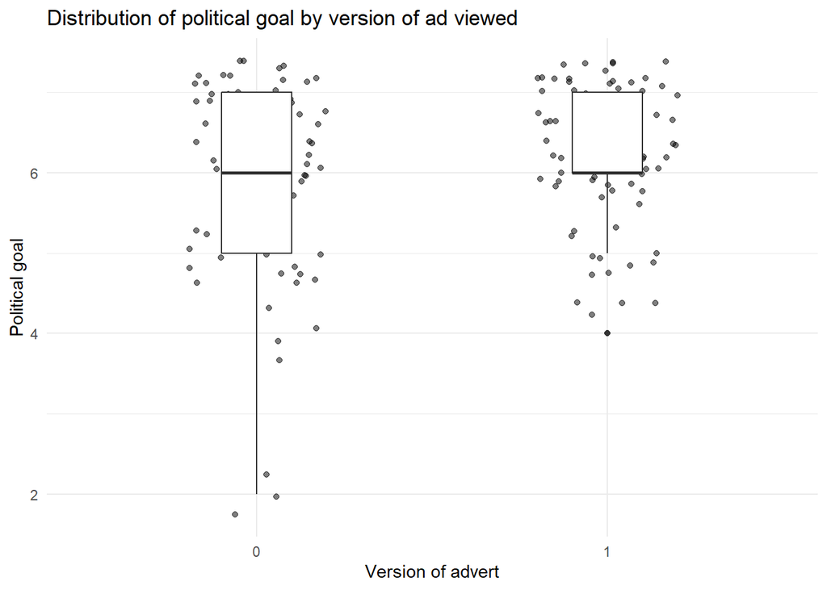

#### Plotting: model predictions

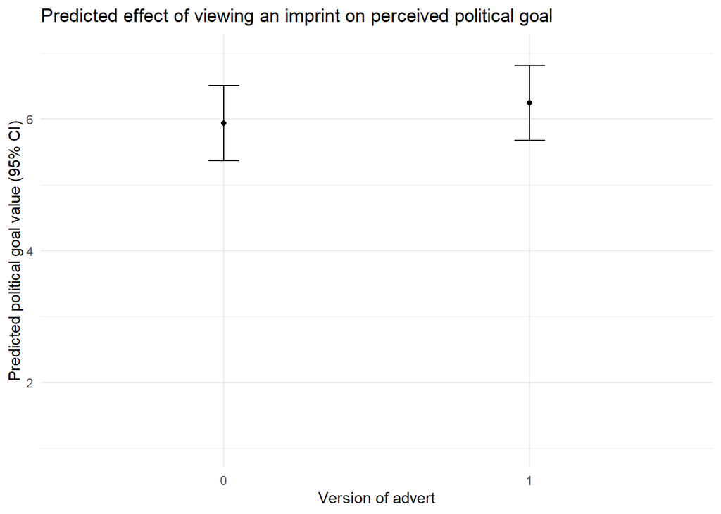

#### Model assumptions

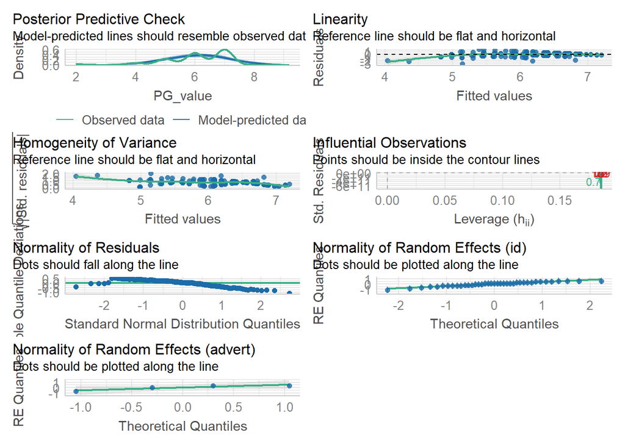

### Hypothesis 1a, outcome: persuasion knowledge

Did the presence of a digital imprint with a piece of campaign material increase participant awareness that the material was trying to persuade them of a certain viewpoint?

- Outcome: PK, numerical 1-7
- Predictor: version, binary factor
- Random effects: id and advert

#### Model

```r
ainform_pk <- lmer(PK ~ version + (1|id) + (1|advert), data = imprint_df)
```

#### Model outcomes: table

|  | Persuasion knowledge |  |  |
| --- | --- | --- | --- |
| Predictors | Estimates | CI | p |
| Intercept | 4.95 | 4.31 – 5.59 | **<0.001** |
| Digital Imprint included | -0.03 | -0.28 – 0.22 | 0.825 |
| Random Effects |  |  |  |
| σ<sup>2</sup> | 0.61 |  |  |
| τ<sub>00</sub> <sub>id</sub> | 0.15 |  |  |
| τ<sub>00</sub> <sub>advert</sub> | 0.37 |  |  |
| ICC | 0.46 |  |  |
| N <sub>id</sub> | 39 |  |  |
| N <sub>advert</sub> | 4 |  |  |
| Observations | 156 |  |  |
| Marginal R<sup>2</sup> / Conditional R<sup>2</sup> | 0.000 / 0.459 |  |  |

#### Plotting: raw data

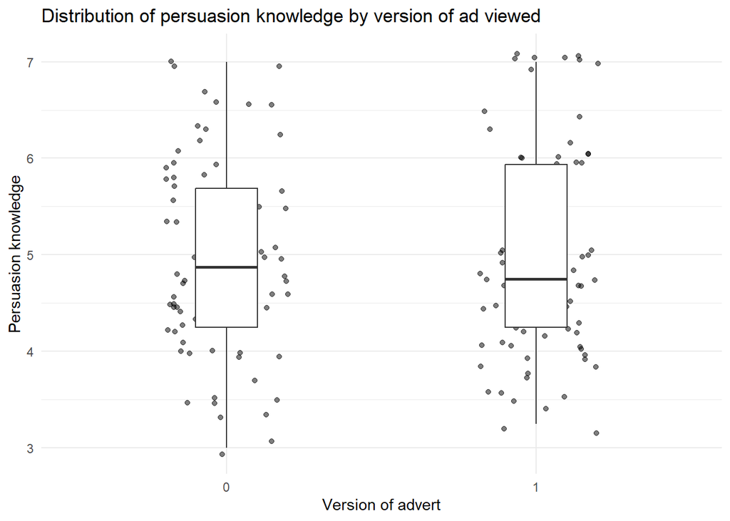

#### Plotting: model predictions

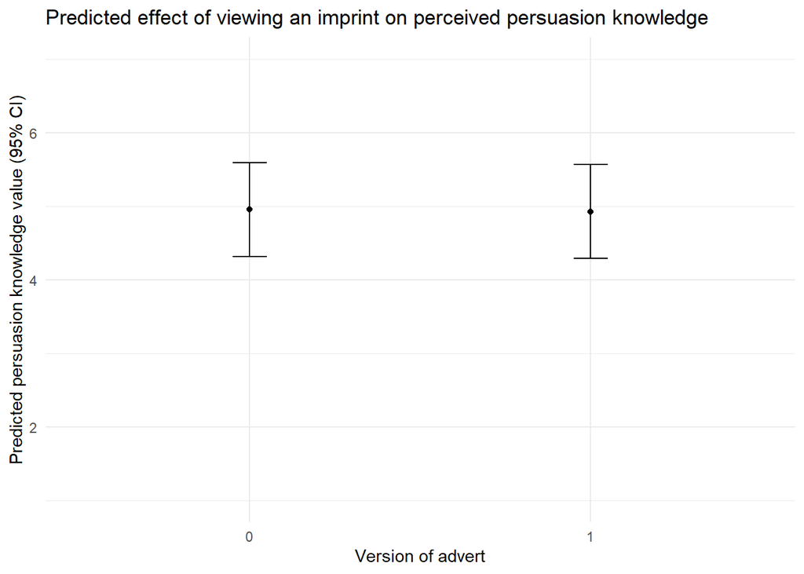

### Hypothesis 1b, outcome: recall of names

Did viewing a digital imprint with a piece of campaign material increase participants memory of the campaigner name?

Correct names:

- Advert 1: Common sense collective: CSC
- Advert 2: Breaking barriers alliance: BBA
- Advert 3: Speak freely inc: SFI
- Advert 4: Campaign for a better Britain: CBB

#### Model

- Outcome: recall, binary factor
- Predictor: version, binary factor

```r
name_recall <- glm(recall ~ version, data = recall_df, family = binomial())
```

#### Table

Recall of campaigner name

|  | Coefficient | SE | Odds ratio | 95% CI(lower) | 95% CI(upper) | p-value |
| --- | --- | --- | --- | --- | --- | --- |
| (Intercept) | -0.64 | 0.24 | 0.53 | 0.33 | 0.84 | 0.01 |
| Imprint viewed with material | 0.48 | 0.33 | 1.62 | 0.85 | 3.10 | 0.14 |

#### Plotting: raw data

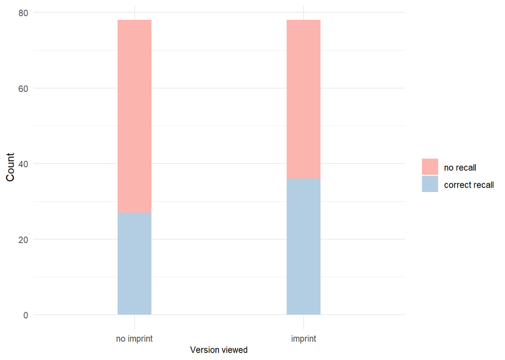

#### Plotting: model predictions

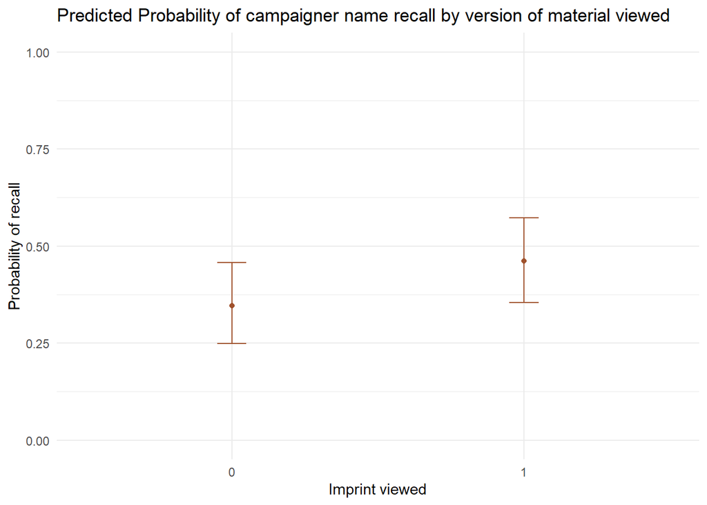

### Hypotheses 1c: outcome: perceived informedness

Did the presence of a digital imprint with a piece of campaign material increase participant’s perception that they had been informed about the source of the content?

- Outcome: informed, numerical 1-7
- Predictor: version, binary factor
- Random effects: id and advert

#### Model

```r
inform_pi <- lmer(informed ~ version + (1|id) + (1|advert), data = imprint_df)
```

#### Model outcomes: table

|  | Perceived informedness |  |  |
| --- | --- | --- | --- |
| Predictors | Estimates | CI | p |
| Intercept | 3.62 | 2.97 – 4.27 | **<0.001** |
| Digital Imprint included | 0.58 | 0.18 – 0.98 | **0.005** |
| Random Effects |  |  |  |
| σ<sup>2</sup> | 1.63 |  |  |
| τ<sub>00</sub> <sub>id</sub> | 0.84 |  |  |
| τ<sub>00</sub> <sub>advert</sub> | 0.26 |  |  |
| ICC | 0.40 |  |  |
| N <sub>id</sub> | 39 |  |  |
| N <sub>advert</sub> | 4 |  |  |
| Observations | 156 |  |  |
| Marginal R<sup>2</sup> / Conditional R<sup>2</sup> | 0.030 / 0.422 |  |  |

#### Plotting: raw data

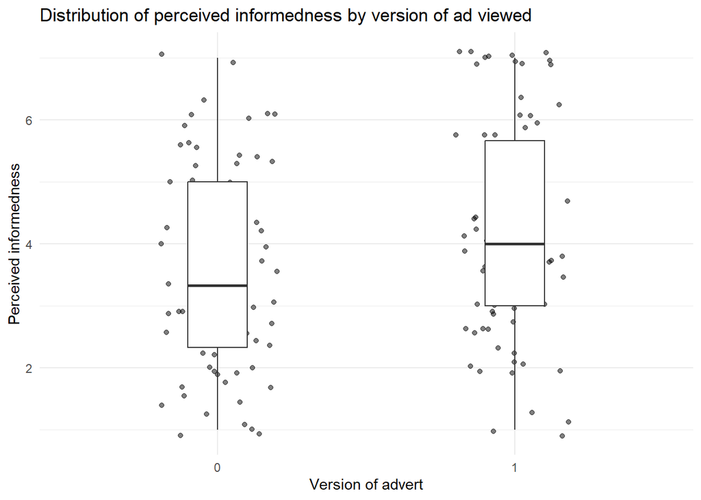

#### Plotting: model predictions

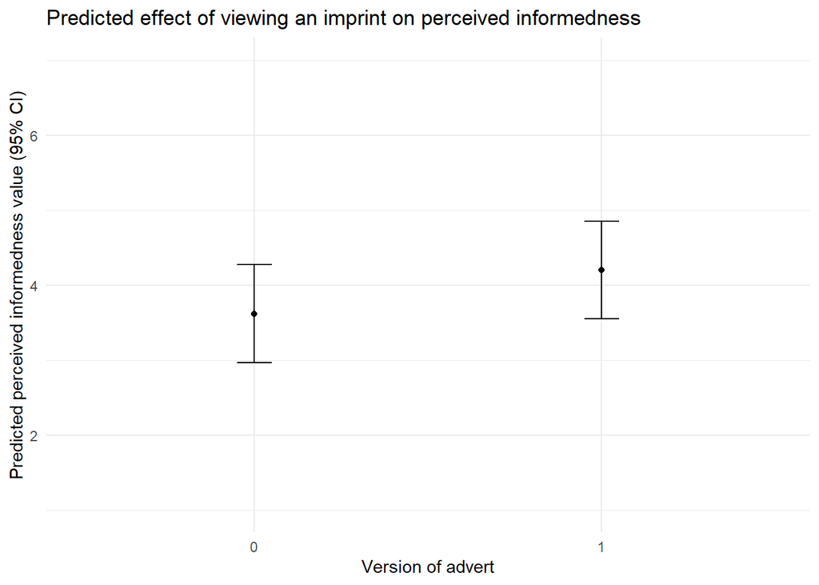

#### Assumptions

### Hypothesis 2a: outcome: correct name recall

Did participants recall a higher number of correct campaigner names when they are trained to pay attention to the source?

- Outcome: name_correct, numerical 0-3
- Predictor: Training.condition

#### Model

```r
correct_name <- lm(name_correct ~ Training.condition, data = training_df)
```

#### Table

|  | Number of names correctly recalled |  |  |
| --- | --- | --- | --- |
| Predictors | Estimates | CI | p |
| Intercept | 1.47 | 1.01 – 1.93 | **<0.001** |
| Trained | 0.26 | -0.36 – 0.87 | 0.403 |
| Observations | 39 |  |  |
| R<sup>2</sup> / R<sup>2</sup> adjusted | 0.019 / -0.007 |  |  |

#### Plotting: Raw data

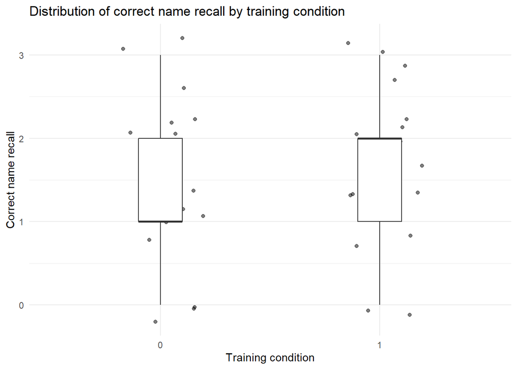

#### Plotting: Model predictions

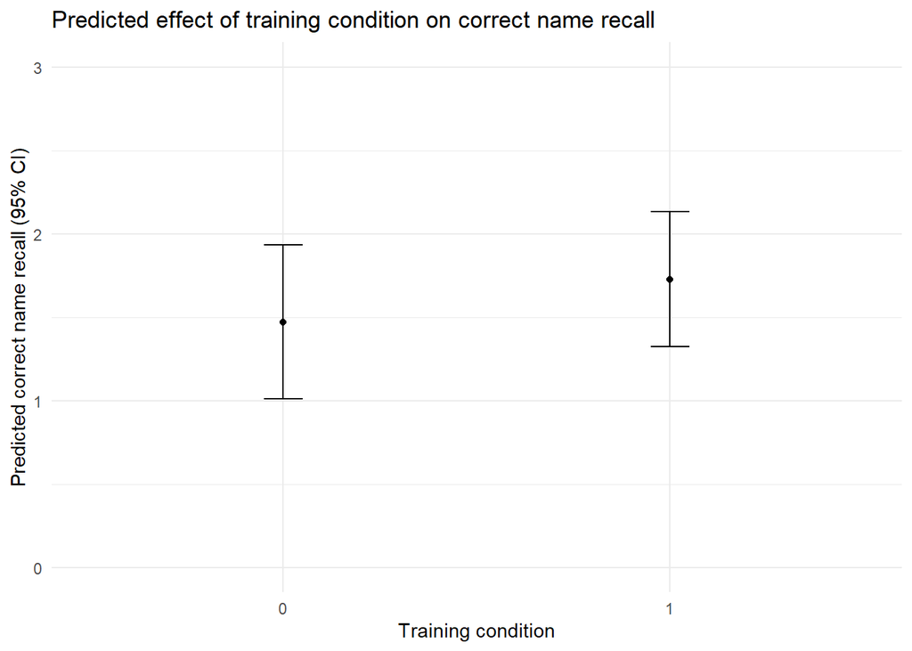

#### Assumptions

### Hypothesis 2b: outcome: percieved informedness

Were trained participants more likely to correctly identify that they were less informed when a digital imprint was *not* present, and more informed when a digital imprint was present, compared to the group who received no training?

#### Model

- Outcome: perceived informedness, numerical 1-7
- fixed effect: training condition x version of imprint viewed (interaction effect)
- random effects: id and advert

```r
inform_training <- lmer(informed ~ Training.condition + version + Training.condition*version + (1|id) + (1|advert), data = imprint_df)
```

#### Table

|  | Perceived Informedness |  |  |
| --- | --- | --- | --- |
| Predictors | Estimates | CI | p |
| Intercept | 3.57 | 2.76 – 4.37 | **<0.001** |
| Training | 0.09 | -0.74 – 0.92 | 0.829 |
| Digital Imprint included | 0.66 | 0.04 – 1.28 | **0.036** |
| Training*imprint | -0.14 | -0.97 – 0.68 | 0.733 |
| Random Effects |  |  |  |
| σ<sup>2</sup> | 1.64 |  |  |
| τ<sub>00</sub> <sub>id</sub> | 0.87 |  |  |
| τ<sub>00</sub> <sub>advert</sub> | 0.26 |  |  |
| ICC | 0.41 |  |  |
| N <sub>id</sub> | 39 |  |  |
| N <sub>advert</sub> | 4 |  |  |
| Observations | 156 |  |  |
| Marginal R<sup>2</sup> / Conditional R<sup>2</sup> | 0.030 / 0.427 |  |  |

#### Plotting: Raw data

Decriptive bivariate statistics for percieved informedness

| Training.condition | version | n | mean_informed | sd_informed | se_informed | ci_upper | ci_lower |
| --- | --- | --- | --- | --- | --- | --- | --- |
| 0 | 0 | 34 | 3.55 | 1.73 | 0.30 | 4.13 | 2.97 |
| 0 | 1 | 34 | 4.25 | 1.70 | 0.29 | 4.82 | 3.67 |
| 1 | 0 | 44 | 3.66 | 1.44 | 0.22 | 4.08 | 3.23 |
| 1 | 1 | 44 | 4.17 | 1.71 | 0.26 | 4.68 | 3.67 |

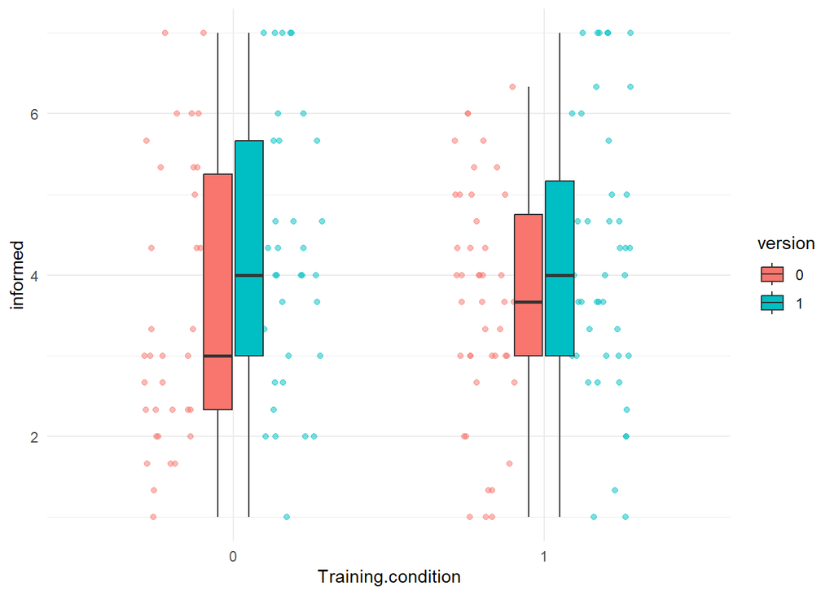

#### Plotting: Model predictions

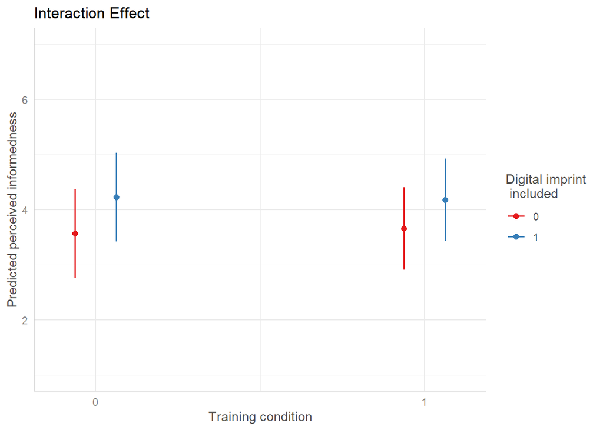

#### Assumptions

### Hypothesis 3: outcome: trustworthiness

Did those informed about the purpose of imprints use their absence/presence to evaluate the trustworthiness and credibility of the posts?

- Outcome: accurate/factual/believable/trustworthy, numerical 1-7
- fixed effect: training condition x version of imprint viewed (interaction effect)
- random effects: id and advert

#### Models

Four models are created through the use of a function for each of the outcome variables, using the following forumula:

model <- lmer(outcome ~ Training.condition + version + Training.condition*version + (1|id) + (1|advert))

#### Tables

|  | Perceived trustworthiness |  |  |
| --- | --- | --- | --- |
| Predictors | Estimates | CI | p |
| Intercept | 3.56 | 2.82 – 4.30 | **<0.001** |
| Training | 0.51 | -0.26 – 1.28 | 0.195 |
| Digital Imprint included | -0.09 | -0.57 – 0.39 | 0.709 |
| Training*imprint | -0.02 | -0.66 – 0.62 | 0.948 |
| Random Effects |  |  |  |
| σ<sup>2</sup> | 0.99 |  |  |
| τ<sub>00</sub> <sub>id</sub> | 0.96 |  |  |
| τ<sub>00</sub> <sub>advert</sub> | 0.21 |  |  |
| ICC | 0.54 |  |  |
| N <sub>id</sub> | 39 |  |  |
| N <sub>advert</sub> | 4 |  |  |
| Observations | 156 |  |  |
| Marginal R<sup>2</sup> / Conditional R<sup>2</sup> | 0.029 / 0.555 |  |  |

|  | Perceived believability |  |  |
| --- | --- | --- | --- |
| Predictors | Estimates | CI | p |
| Intercept | 4.68 | 3.93 – 5.43 | **<0.001** |
| Training | 0.22 | -0.54 – 0.98 | 0.565 |
| Digital Imprint included | -0.41 | -0.93 – 0.10 | 0.113 |
| Training*imprint | 0.52 | -0.16 – 1.21 | 0.134 |
| Random Effects |  |  |  |
| σ<sup>2</sup> | 1.14 |  |  |
| τ<sub>00</sub> <sub>id</sub> | 0.85 |  |  |
| τ<sub>00</sub> <sub>advert</sub> | 0.25 |  |  |
| ICC | 0.49 |  |  |
| N <sub>id</sub> | 39 |  |  |
| N <sub>advert</sub> | 4 |  |  |
| Observations | 156 |  |  |
| Marginal R<sup>2</sup> / Conditional R<sup>2</sup> | 0.034 / 0.507 |  |  |

|  | Perceived accuracy |  |  |
| --- | --- | --- | --- |
| Predictors | Estimates | CI | p |
| Intercept | 4.21 | 3.51 – 4.90 | **<0.001** |
| Training | 0.13 | -0.60 – 0.86 | 0.722 |
| Digital Imprint included | -0.12 | -0.60 – 0.37 | 0.637 |
| Training*imprint | 0.03 | -0.62 – 0.68 | 0.918 |
| Random Effects |  |  |  |
| σ<sup>2</sup> | 1.02 |  |  |
| τ<sub>00</sub> <sub>id</sub> | 0.79 |  |  |
| τ<sub>00</sub> <sub>advert</sub> | 0.19 |  |  |
| ICC | 0.49 |  |  |
| N <sub>id</sub> | 39 |  |  |
| N <sub>advert</sub> | 4 |  |  |
| Observations | 156 |  |  |
| Marginal R<sup>2</sup> / Conditional R<sup>2</sup> | 0.004 / 0.492 |  |  |

|  | Perceived fact versus opinion |  |  |
| --- | --- | --- | --- |
| Predictors | Estimates | CI | p |
| Intercept | 3.05 | 2.19 – 3.91 | **<0.001** |
| Training | 0.63 | -0.28 – 1.53 | 0.173 |
| Digital Imprint included | 0.34 | -0.26 – 0.94 | 0.268 |
| Training*imprint | -0.51 | -1.32 – 0.30 | 0.213 |
| Random Effects |  |  |  |
| σ<sup>2</sup> | 1.58 |  |  |
| τ<sub>00</sub> <sub>id</sub> | 1.21 |  |  |
| τ<sub>00</sub> <sub>advert</sub> | 0.30 |  |  |
| ICC | 0.49 |  |  |
| N <sub>id</sub> | 39 |  |  |
| N <sub>advert</sub> | 4 |  |  |
| Observations | 156 |  |  |
| Marginal R<sup>2</sup> / Conditional R<sup>2</sup> | 0.016 / 0.496 |  |  |

#### Plotting: raw data

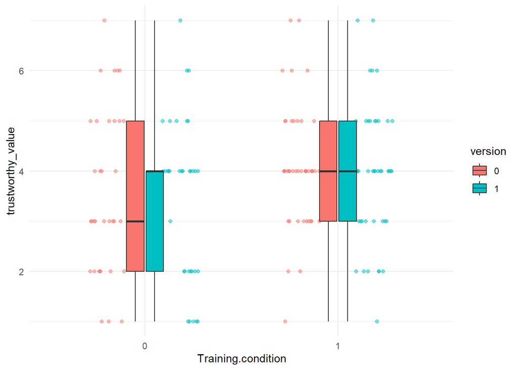

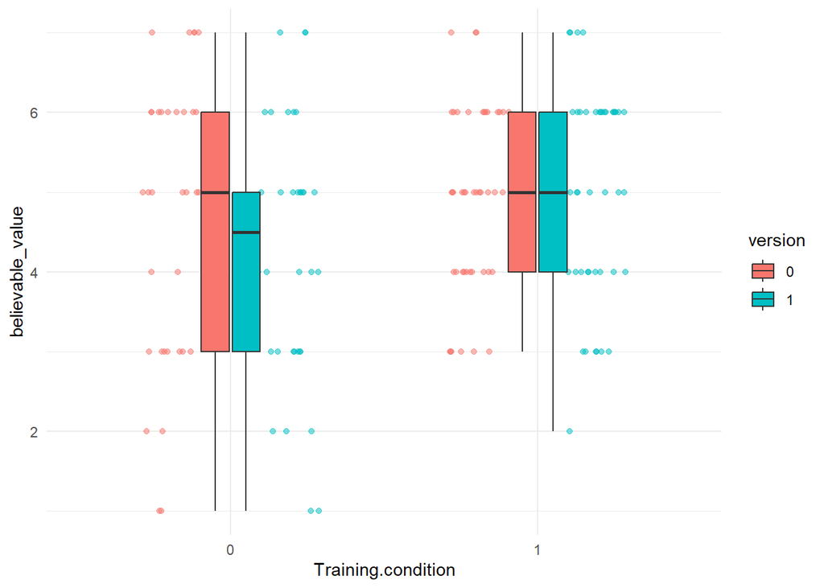

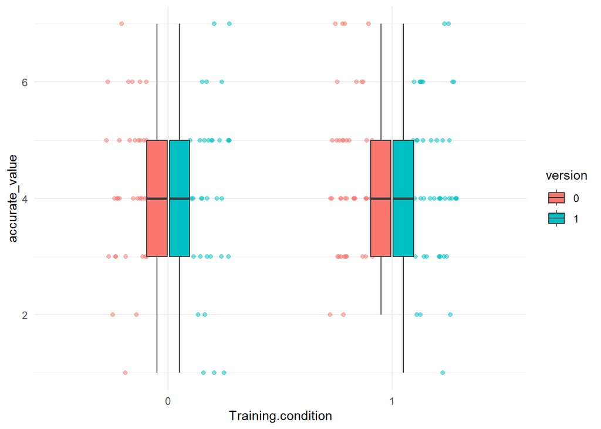

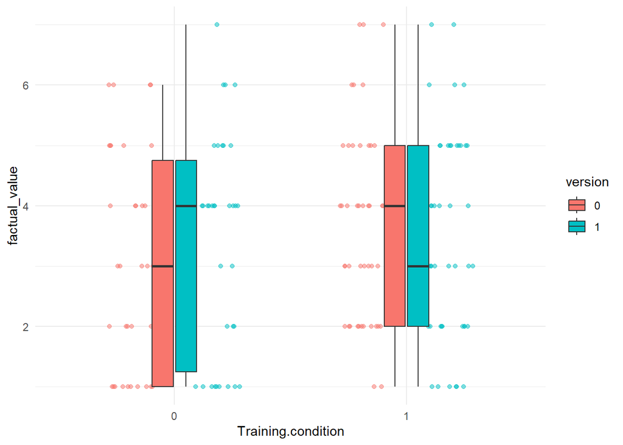

#### Plotting: model predictions

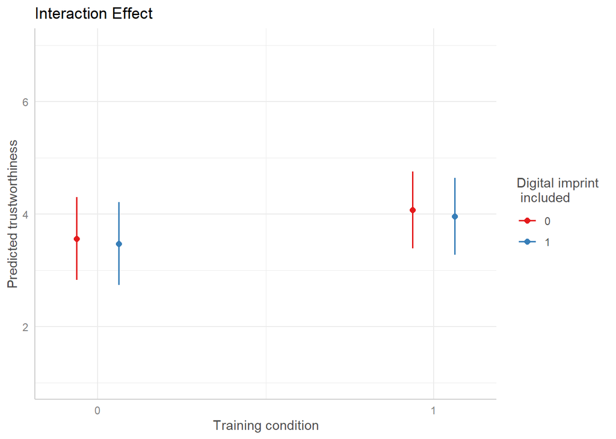

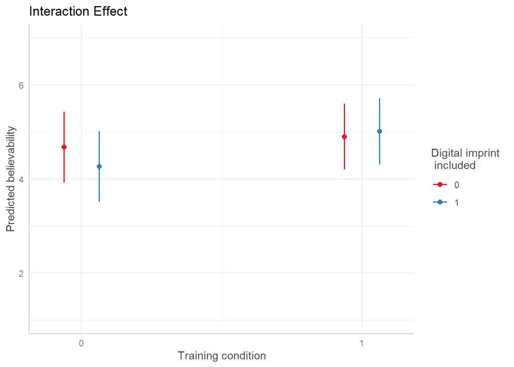

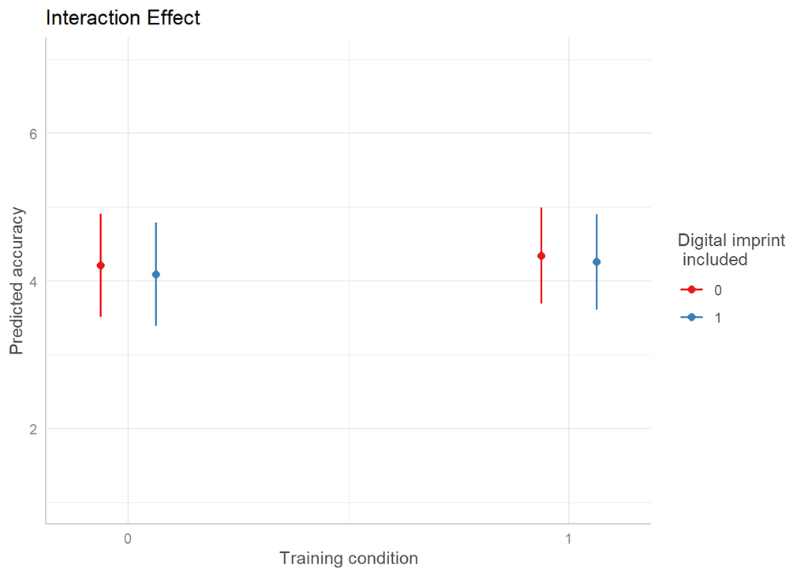

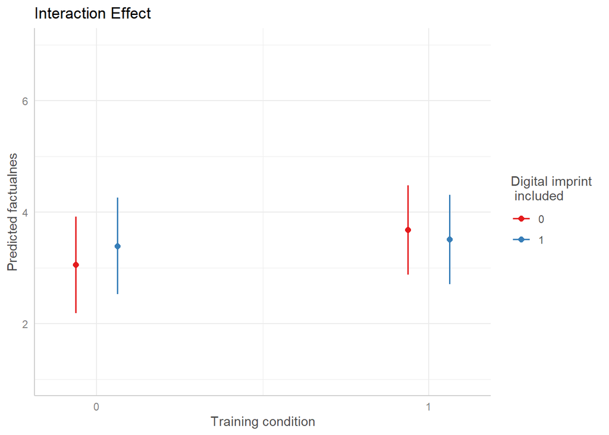

### Hypothesis 4: outcome: confidence in regulation

Does being informed explicitly about the purpose of digital imprints and their relation to regulatory compliance increase perceptions that political advertising is sufficiently regulated in the UK?

This model uses the training_df dataframe.

- Outcome: confidence in regulation, numerical 1-7
- Predictor: training condition

#### Model

```r
regulation_model <- lm(election_reg ~ Training.condition, data = training_df)
```

#### Table

|  | Perceived sufficiency of advertising regulation |  |  |
| --- | --- | --- | --- |
| Predictors | Estimates | CI | p |
| Intercept | 2.82 | 2.04 – 3.61 | **<0.001** |
| Trained | 0.45 | -0.60 – 1.50 | 0.391 |
| Observations | 39 |  |  |
| R<sup>2</sup> / R<sup>2</sup> adjusted | 0.020 / -0.006 |  |  |

#### Plotting: raw data

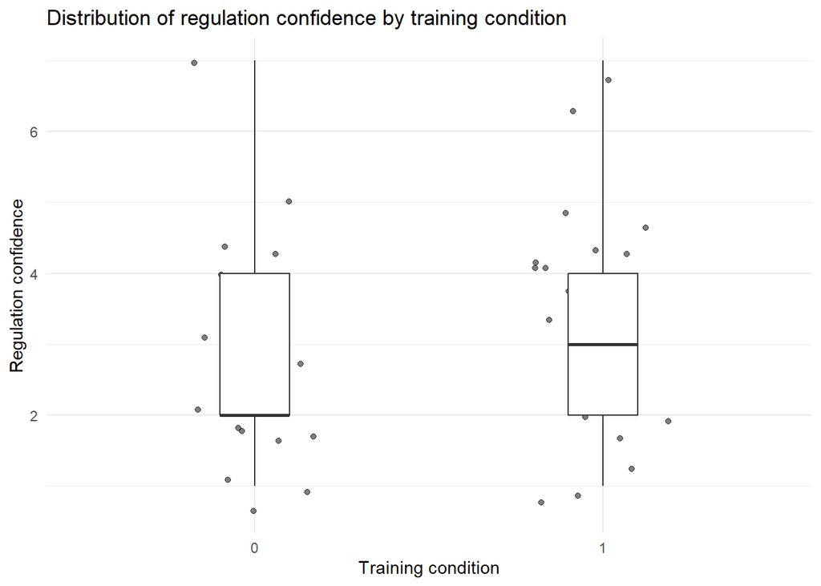

#### Plotting: model predictions

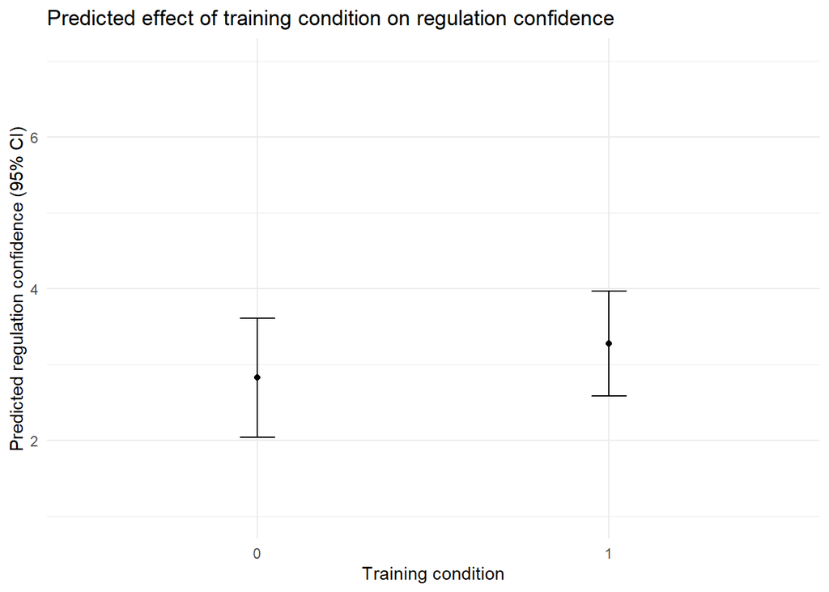

#### Model assumptions